# HW2_IE360

# TIME SERIES

After doing some operations, we have the data we can work on. To be able to plot the time series of the UGS, we eliminated the last four rows since these are the data rows that we will make predictions. The first 28 rows is used to build time series. To be able to plot the time series, we started from 2000 Q1 to 2006 Q4. Time series is plotted below.

```r
hw2_data_train <- hw2_data[is.na(hw2_data$Unleaded.Gasoline.Sale..UGS.)==FALSE,]
str(hw2_data_train)
```

```
## 'data.frame':    28 obs. of  11 variables:
##  $ Quarter                              : 'yearqtr' num  2000 Q1 2000 Q2 2000 Q3 2000 Q4 ...
##  $ Unleaded.Gasoline.Sale..UGS.         : int  1128971 1199569 1370167 1127548 1033918 1019754 1209916 1002789 893722 1027252 ...
##  $ RNUV                                 : num  0.0146 0.0205 0.0207 0.0163 0.0071 0.0051 0.0041 0.0048 0.0012 0.0032 ...
##  $ X..LPG.Vehicles..NLPG.               : int  940000 941000 943500 948000 950000 955000 967500 990000 1000000 1001000 ...
##  $ Price.of.Unleaded.Gasoline..PU.      : num  469 459 440 402 412 ...
##  $ Price.of.Diesel.Gasoline..PG.        : num  356 345 327 301 306 ...
##  $ X..Unleaded.Gasoline.Vehicles..NUGV. : int  4647500 4742876 4840931 4919685 4954754 4980204 5000446 5024693 5030810 5046960 ...
##  $ X..of.Diesel.Gasoline.Vehicles..NDGV.: num  282 284 287 288 288 ...
##  $ GNP.Agriculture                      : int  1040173 1760460 6974808 3267125 1004528 1449357 5890424 1940854 832953 1419764 ...
##  $ GNP.Commerce                         : int  3483132 4525451 5915204 4929778 3418387 4359831 5925547 4559190 3374849 4363782 ...
##  $ GNP.Total                            : int  18022686 21797130 30050207 24480153 15832648 20296918 28017963 22656812 18393446 20382635 ...
```

```r
hw2_data_test<- hw2_data[is.na(hw2_data$Unleaded.Gasoline.Sale..UGS.)==TRUE,]
hw2_data_ts <- ts(hw2_data_train,freq=4,start=c(2000,1))
str(hw2_data_ts)
```

```
##  Time-Series [1:28, 1:11] from 2000 to 2007: 2000 2000 2000 2001 2001 ...
##  - attr(*, "dimnames")=List of 2
##   ..$ : NULL
##   ..$ : chr [1:11] "Quarter" "Unleaded.Gasoline.Sale..UGS." "RNUV" "X..LPG.Vehicles..NLPG." ...
```

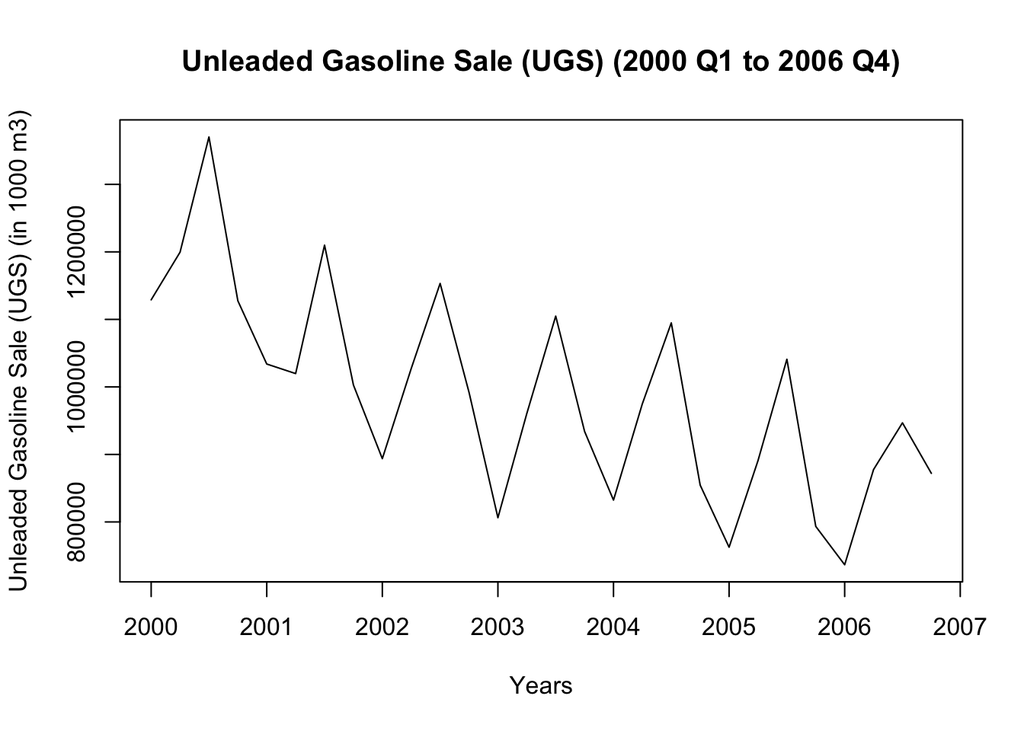

```r
ts.plot(hw2_data_ts[,c("Unleaded.Gasoline.Sale..UGS.")] , main="Unleaded Gasoline Sale (UGS) (2000 Q1 to 2006 Q4)" ,
        ylab="Unleaded Gasoline Sale (UGS) (in 1000 m3)",xlab="Years")
```

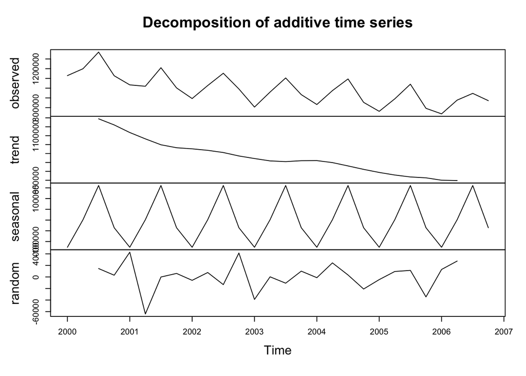

```r
decomposed_hw2_data<-decompose(hw2_data_ts[,c("Unleaded.Gasoline.Sale..UGS.")], type="additive")
plot(decomposed_hw2_data)
```

As we can see from the plot, we have decreasing trend and the seasonality. By means of stationary, we can say that because of the decreasing trend in the data, we do not have the stationary mean however variance is stationary.

## Auto correlation is drawn

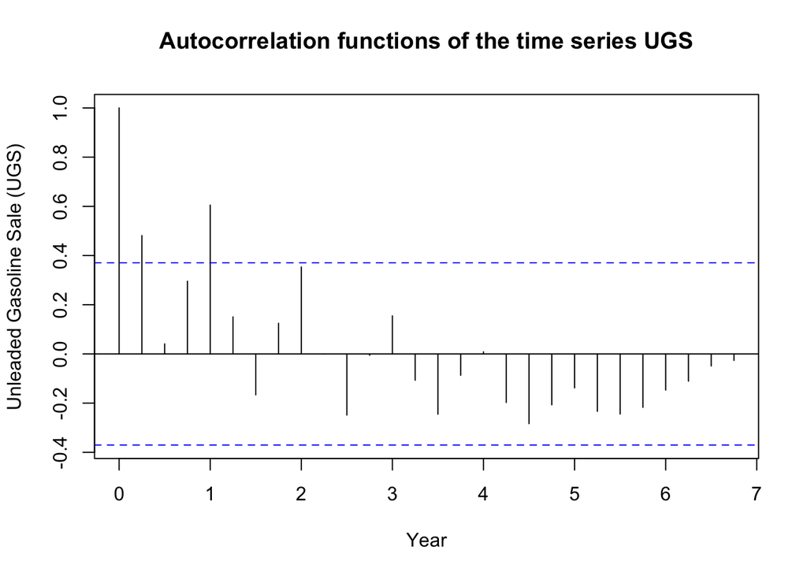

```r
AutoCorrelation <- acf(hw2_data_ts[,c("Unleaded.Gasoline.Sale..UGS.")],lag.max=28, plot = FALSE)
plot(AutoCorrelation, xlab = "Year",ylab= "Unleaded Gasoline Sale (UGS)",main = "Autocorrelation functions of the time series UGS")
```

The plot above represents the autocorrelation of the UGS values. Dashed lines shows the critical values and as can be seen from the data, lag1 and lag4 are above the critical values. This implies that while building the model, lag1 and lag4 values should be considered.

# REGRESSION

Trend and seasonality are defined and added to the data. Besides, lag1 and lag4 values are found and seasonality is defined as factor while trend is numeric.

```r
trend=c(1:32)
hw2_data$trend=trend
quartes_info=rep(1:4,8)
hw2_data$quartes_info=quartes_info

hw2_data$lagged_values_lag1= NA

for(i in 1:28){
  hw2_data$lagged_values_lag1[i+1] = hw2_data$"Unleaded.Gasoline.Sale..UGS."[i]
}

#hw2_data$lagged_values_lag1

hw2_data$lagged_values_lag4= NA

for(i in 1:28){
  hw2_data$lagged_values_lag4[i+4] = hw2_data$"Unleaded.Gasoline.Sale..UGS."[i]
}

#hw2_data$lagged_values_lag4

#summary(hw2_data)

hw2_data$quartes_info=as.factor(hw2_data$quartes_info)
hw2_data$trend=as.numeric(hw2_data$trend)

str(hw2_data)
```

```
## 'data.frame':    32 obs. of  15 variables:
##  $ Quarter                              : 'yearqtr' num  2000 Q1 2000 Q2 2000 Q3 2000 Q4 ...
##  $ Unleaded.Gasoline.Sale..UGS.         : int  1128971 1199569 1370167 1127548 1033918 1019754 1209916 1002789 893722 1027252 ...
##  $ RNUV                                 : num  0.0146 0.0205 0.0207 0.0163 0.0071 0.0051 0.0041 0.0048 0.0012 0.0032 ...
##  $ X..LPG.Vehicles..NLPG.               : int  940000 941000 943500 948000 950000 955000 967500 990000 1000000 1001000 ...
##  $ Price.of.Unleaded.Gasoline..PU.      : num  469 459 440 402 412 ...
##  $ Price.of.Diesel.Gasoline..PG.        : num  356 345 327 301 306 ...
##  $ X..Unleaded.Gasoline.Vehicles..NUGV. : int  4647500 4742876 4840931 4919685 4954754 4980204 5000446 5024693 5030810 5046960 ...
##  $ X..of.Diesel.Gasoline.Vehicles..NDGV.: num  282 284 287 288 288 ...
##  $ GNP.Agriculture                      : int  1040173 1760460 6974808 3267125 1004528 1449357 5890424 1940854 832953 1419764 ...
##  $ GNP.Commerce                         : int  3483132 4525451 5915204 4929778 3418387 4359831 5925547 4559190 3374849 4363782 ...
##  $ GNP.Total                            : int  18022686 21797130 30050207 24480153 15832648 20296918 28017963 22656812 18393446 20382635 ...
##  $ trend                                : num  1 2 3 4 5 6 7 8 9 10 ...
##  $ quartes_info                         : Factor w/ 4 levels "1","2","3","4": 1 2 3 4 1 2 3 4 1 2 ...
##  $ lagged_values_lag1                   : int  NA 1128971 1199569 1370167 1127548 1033918 1019754 1209916 1002789 893722 ...
##  $ lagged_values_lag4                   : int  NA NA NA NA 1128971 1199569 1370167 1127548 1033918 1019754 ...
```